# python

[figure not shown]

Hier soll es hingehen: Auswertung von Praktikumsversuchen:

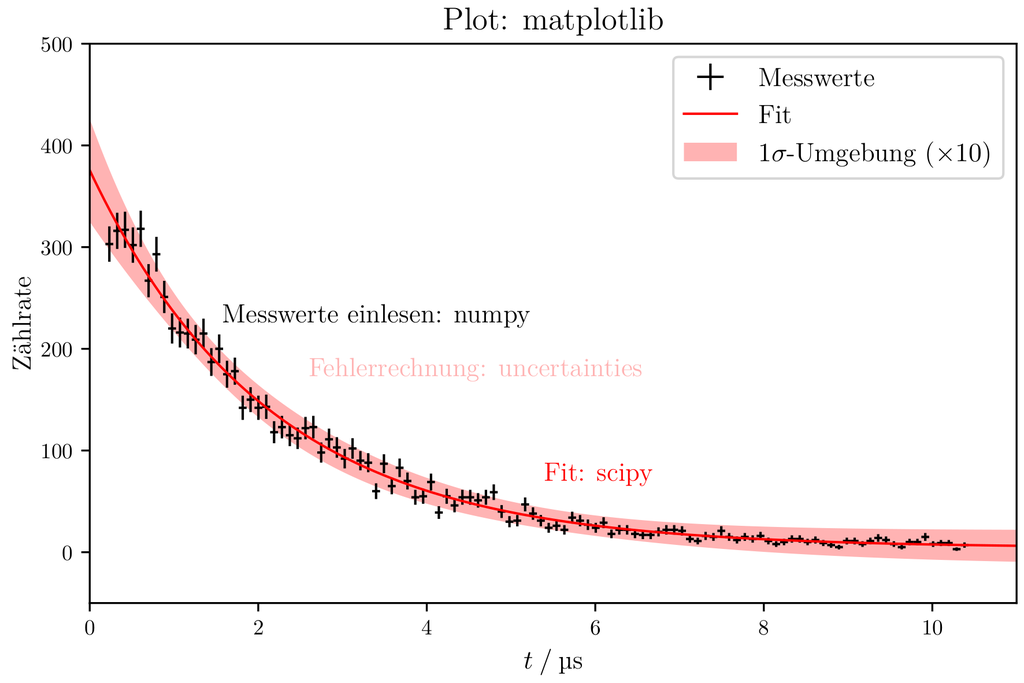

Versuch aus dem Fortgeschrittenen-Praktikum: Lebensdauer kosmischer Myonen

```python
%%javascript
$.getScript('https://kmahelona.github.io/ipython_notebook_goodies/ipython_notebook_toc.js')
```

# Grundlagen

Eine Programmiersprache wie Python lässt sich nicht an einem Tag lernen.

Hier geben wir einen kurzen Überblick über die wichtigsten Konzepte.

Keine Angst: Zum Erstellen von Plots und für einfache Auswertungen muss man nicht viel Python können!

Die folgenden Beispiele kann man auf der Kommandozeile durch ausführen von

```
ipython
```

ausprobieren.

## Einfachstes Beispiel

```python
print('Hello, World!')
```

```
Hello, World!
```

## Kommentare

- Sehr wichtig für die Leute, die mit euch Arbeiten
- Auch für euch selbst zwei Wochen später

Alles was in Python hinter einem `#` steht, wird nicht als Code betrachtet und dient als Kommentar.

```python
# This prints the traditional greeting to the console
print("Hello, World!")
```

```
Hello, World!
```

Kommentare sollten nicht erklären, was der Code tut, sondern warum.

Kommentare, wie jeder andere Code, sollten auf englisch sein.

## Variablen

Man kann einem Objekt einen Namen geben:

```python
a = 2
b = 3
```

Variablennamen können auch überschrieben werden:

```python
a = 42
b = a

a = 0
b
```

```
42
```

- Namen verweisen auf Objekte
- Mehrere Namen können auf das gleiche Objekt zeigen

# Datentypen

## Einfache Datentypen

### Booleans

`True` und `False`

Logische Operatoren: `and`, `or`, `not`

```python
True and False
```

```
False
```

```python
True or False
```

```
True
```

```python
not True
```

```
False
```

`None` oder leere Objekte verhalten sich wie `False`, andere wie `True`

```python
'' or True
```

```
True
```

```python
'Hallo' and True
```

```
True
```

### Zahlen

Ganze Zahlen: `42`  
Kommazahlen: `3.14`  
Komplexe Zahlen: `3 + 2j`

Rechenoperatoren:

- `+`, `-`, `*`
- `**` (Potenzieren: `2**3` → `8`)
- `/` (`3 / 2` → `1.5`)
- `//` (Ganzzahldivision: `3 // 2` → `1`)
- `%` (Modulo-Operation, Divisionsrest: `7 % 4` → `3`)

```python
x = 5
y = 3
x + y
```

```
8
```

Rechenoperationen können geklammert werden

```python
a = 2 + 4 / 5 + 1
b = (2 + 4) / 5 + 1
c = (2 + 4) / (5 + 1)
```

```python
print(a, b, c)
```

```
3.8 2.2 1.0
```

```python
a = 3 + 2j
b = 1 + 1j

print(a + b, a*b, abs(b))
```

```
(4+3j) (1+5j) 1.4142135623730951
```

Vergleichsoperatoren geben `True` oder `False` zurück

- `==`, `!=`
- `>`, `<`, `>=`, `<=`

```python
x = 5
y = 3
x < y
```

```
False
```

Mehrere Vergleichsoperatoren können in einem Ausdruck stehen:

```python
a = 3.8
b = 2.2
c = 1
c < b < a
```

```
True
```

```python
c < a < b
```

```
False
```

### Strings

Stehen in `'` oder `"`. (Für eins entscheiden)

```python
foo = 'foo'
bar = "bar"
```

Strings können mit `+` konkateniert werden:

```python
foo + " " + bar
```

```
'foo bar'
```

Strings können mit `*` vervielfacht werden

```python
foo * 4
```

```
'foofoofoofoo'
```

Strings können mit `[]` indiziert werden

```python
foo[0]
```

```
'f'
```

Können beliebige Unicode Symbole enthalten

```python
print('π ist genau 3, Erwin Schrödinger')
```

```
π ist genau 3, Erwin Schrödinger
```

### None

Stellt das Fehlen eines Wertes dar.

Wird häufig für Standardwerte von Funktionen verwendet.

```python
print(None)
```

```
None
```

Funktionen, die 'nichts' zurückgeben, geben `None` zurück:

```python
print('test')
```

```
test
```

```python
a = print('test')
```

```
test
```

```python
print(a)
```

```
None
```

## Sammlungen (Collections)

Speichern mehrere Objekte

### Listen

- Veränderbar
- Gedacht für mehrere Werte vom selben Typ

```python
names = ['foo', 'bar']
```

Listen können mit `[]` indiziert werdern

```python
names[1]
```

```
'bar'
```

Man kann Werte an Listen anhängen:

```python
names.append('baz')
names
```

```
['foo', 'bar', 'baz']
```

Negative Indizes (beginnend mit `-1`), indizieren die Liste rückwärts

```python
names[-1]
```

```
'baz'
```

Man kann auch Teillisten indizieren.  
`names[Anfang:Ende]` liefert eine Teilliste mit den Werten von `names[Anfang]` bis `names[Ende-1]`:

```python
names[1:3]
```

```
['bar', 'baz']
```

Listen werden mit `+` zusammengeführt:

```python
names + ['thing']
```

```
['foo', 'bar', 'baz', 'thing']
```

Listen können mit `*` vervielfacht werden:

```python
names * 3
```

```
['foo', 'bar', 'baz', 'foo', 'bar', 'baz', 'foo', 'bar', 'baz']
```

Die Liste kann auch erweitert werden:

```python
names.extend(['quux'])
names
```

```
['foo', 'bar', 'baz', 'quux']
```

Listen sind veränderbar, man kann ihnen Werte zuweisen:

```python
names[1] = 'new'
names
```

```
['foo', 'new', 'baz', 'quux']
```

Mit `in` wird überprüft ob ein Wert in der Liste ist:

```python
weekdays = ['Mo', 'Di', 'Mi', 'Do', 'Fr', 'Sa', 'So']
'Mo' in weekdays
```

```
True
```

### Tupel

- Gedacht für Werte mit unterschiedlichen Typen
- Werden an allen möglichen Stellen von python erzeugt

```python
tup = (5, 3)
tup
```

```
(5, 3)
```

Können wahlweise auch ohne Klammern geschrieben werden (wenn es eindeutig ist).

```python
tup = 5, 3
tup
```

```
(5, 3)
```

```python
a = 5
b = 3
a, b = b, a
```

```python
print("a =", a)
print("b =", b)
```

```
a = 3
b = 5
```

```python
tup[0]
```

```
5
```

Einträge nach Erzeugung unveränderbar:

```python
tup[1] = 7
```

```
---------------------------------------------------------------------------
TypeError                                 Traceback (most recent call last)
Input In [42], in <cell line: 1>()
----> 1 tup[1] = 7

TypeError: 'tuple' object does not support item assignment
```

### Dictionaries

```python
numbers = { 'one': 1, 'two': 2, 'three': 3 }
```

```python
numbers['two']
```

```
2
```

Dictionaries sind extrem hilfreich, zum Beispiel um die verschiedene Datensätze der gleichen Messung zusammenzufassen. So wird es einfacher dieselbe Analyse auf die einzelnen Datensätze anzuwenden.

```python
data = {'Cu': [1.1, 1.2, 1.3, 1.4], 'Fe': [0.7, 0.8, 0.9, 1.0]}
data['Cu']
```

```
[1.1, 1.2, 1.3, 1.4]
```

Leere Dictionaries werden z.B. mit der Funktion `dict()`erstellt

```python
data = dict()
data
```

```
{}
```

```python
data["Fe"] = [1.1, 1.2, 1.3, 1.4]
data
```

```
{'Fe': [1.1, 1.2, 1.3, 1.4]}
```

```python
data["Cu"] = [0.7, 0.8, 0.9, 1.0]
data
```

```
{'Fe': [1.1, 1.2, 1.3, 1.4], 'Cu': [0.7, 0.8, 0.9, 1.0]}
```

```python
data["Au"] = [0.2, 0.3, 0.1, 0.5]
data
```

```
{'Fe': [1.1, 1.2, 1.3, 1.4],
 'Cu': [0.7, 0.8, 0.9, 1.0],
 'Au': [0.2, 0.3, 0.1, 0.5]}
```

# Kontrollstrukturen

Die Zeilen eines Python-Programms werden nacheinander ausgeführt.

Sogennante *Kontrollstrukturen* erlauben es, den Ablauf zu steuern.

## `if` / `elif` / `else`

```python
a = 3

if a == 1:
    # muss eingerückt werden, 4 spaces:
    print('foo')
elif a == 2:
    print('bar')
else:
    print('baz')
```

```
baz
```

## `while`

Wiederholen, solange eine Bedingung erfüllt ist.

```python
i = 0
while i < 5:
    print(i)
    i += 1

# there has to be a better way!
```

```
0
1
2
3
4
```

## `for`

Wiederholen für jedes Elements (z.B. einer Liste)

```python
data = [10, 42, -1]

for x in data:
    # Wir können auf das jetzige Element als "x" zugreifen
    print(2 * x)
```

```
20
84
-2
```

klassische for-Schleife mit `range`:

```python
for i in range(5):
    print(i)
```

```
0
1
2
3
4
```

```python
for i in range(2, 5):
    print(i)
```

```
2
3
4
```

```python
for i in range(2, 10, 2):
    print(i)
```

```
2
4
6
8
```

```python
for i in range(10, 3, -1):
    print(i)
```

```
10
9
8
7
6
5
4
```

```python
weekdays = ['Mo', 'Di', 'Mi', 'Do', 'Fr', 'Sa', 'So']
for day in weekdays:
    print("Heute ist", day)
```

```
Heute ist Mo
Heute ist Di
Heute ist Mi
Heute ist Do
Heute ist Fr
Heute ist Sa
Heute ist So
```

Zwei sehr nützliche Funktionen sind `enumerate` und `zip`

```python
for i, day in enumerate(weekdays):
    print(day, " ist der ", i+1, ". Tag der Woche", sep="")
```

```
Mo ist der 1. Tag der Woche
Di ist der 2. Tag der Woche
Mi ist der 3. Tag der Woche
Do ist der 4. Tag der Woche
Fr ist der 5. Tag der Woche
Sa ist der 6. Tag der Woche
So ist der 7. Tag der Woche
```

Was `enumerate()` macht:

```python
list(enumerate(weekdays))
```

```
[(0, 'Mo'), (1, 'Di'), (2, 'Mi'), (3, 'Do'), (4, 'Fr'), (5, 'Sa'), (6, 'So')]
```

```python
voltages = [1, 3, 5]
currents = [1, 5, 1]

for voltage, current in zip(voltages, currents):
    print('R =', voltage / current)
```

```
R = 1.0
R = 0.6
R = 5.0
```

Was `zip()` macht:

```python
list(zip(voltages, currents))
```

```
[(1, 1), (3, 5), (5, 1)]
```

Iterieren über die Einträge von `dict`

```python
translations = {
    'foot': 'Fuß',
    'ball': 'Ball',
    'goal': 'Tor',
}

for e, g in translations.items():
    print(e, g)
```

```
foot Fuß
ball Ball
goal Tor
```

Übungen 1, 2, und 3 können bearbeitet werden.

# Funktionen

Mit Funktionen lässt sich Code leicht wiederverwenden. Eine Funktion nimmt Parameter, verarbeitet sie und gibt Ergebnisse zurück.

```python
print('Hello!')
```

```
Hello!
```

```python
len([1, 2, 3, 4, 5])
```

```
5
```

Viele Funktionen haben mehrere Parameter, einige können sogar beliebig viele haben:

```python
print(1, 2, 3, 4, 5)
```

```
1 2 3 4 5
```

Viele Funktionen haben optionale Parameter mit eigenem Namen, sogenannte "keyword arguments":

```python
print(1, 2, 3, 4, 5, sep=', ')
```

```
1, 2, 3, 4, 5
```

Objekte haben auch Funktionen (diese nennt man Methoden):

```python
s = 'test'
s.upper()
```

```
'TEST'
```

```python
'foo bar baz'.split()
```

```
['foo', 'bar', 'baz']
```

In IPython kann man wie folgt auf die Dokumentation einer Funktion zugreifen:

```python
print?
```

Ansonsten findet man ausführliche Erklärungen in der offiziellen Dokumentation.

## Eigene Funktionen definieren mit `def`

Um mehrfach benötigten Code einfacher zu nutzen, können Funktionen definiert werden.

Vorteile:

- Weniger Code
- Änderungen nur an einer Stelle notwending

```python
def add(x, y):
    z = x + y
    return z

add(2, 2)
```

```
4
```

Mit dem `return` Statement wird die Funktion beendet und Ergebnisse zurückgeben.

Es können auch mehrere Werte zurückgeben werden:

```python
def divide(x, y):
    return x // y, x % y

n, rest = divide(5, 3)
n, rest
```

```
(1, 2)
```

Funktionen können sich selbst aufrufen (Rekursion)

```python
def factorial(n):
    if n == 0:
        return 1
    else:
        return n * factorial(n - 1)

factorial(4)
```

```
24
```

## Module und `import`

In Python kann man Code in einzelne Module portionieren.

Es stehen bereits unglaublich viele Module für Python zur Verfügung.

Gerade für das wissenschaftliche Arbeiten ist eigentlich alles da was gebraucht wird und noch viel mehr.

Wird etwas aus einem anderen Modul gebraucht, importiert man es.

Zahlreiche Module sind Teil jeder Python Installation, die sogenannte "standard library": https://docs.python.org/3/library/

Viele weitere Module habt ihr mit Anaconda installiert

```python
import os

os.listdir('.')
```

```
['plot.pdf',
 'uncertainties.ipynb',
 'README.md',
 'python.ipynb',
 'numeric-python.ipynb',
 'data',
 'matplotlib.ipynb',
 'Makefile',
 'plot_2.pdf',
 'images',
 'muon_plot.py',
 'header-matplotlib.tex',
 '.gitignore',
 'matplotlibrc_muon',
 'scientific-python.ipynb',
 'build',
 'plot_1.pdf']
```

Für das Importieren einzelner Funktionen gibt es den Befehl:

```python
from time import sleep

print('hello')
sleep(1)
print('world')
```

```
hello
world
```

Den Modulen können mit `as` neue Namen gegeben werden

Viele Module haben Konventionen für den Kurznamen, die ihr verwenden solltet

```python
import numpy as np

np.sum([1, 2]) # siehe numpy Kurs
```

```
3
```

# Auslagern in Python-Dateien

- Python-Dateien haben die Endung `.py`
- Ausführen mit `python programm.py`
- Einzelne Python-Dateien (Endung `.py`) kann man als Module benutzen.  
  Liegt eine Datei `test.py` im selben Ordner, so kann der Inhalt mit `import test` in einer weiteren Datei verwendet werden.
- Die Datei muss mit dem Encoding UTF-8 abgespeichert werden. (Standard in modernen Editoren / Betriebssystemen)

Es folgt ein fertiges Python-Programm.

Speichert es als `primes.py` ab und startet es aus dem Terminal mit `python primes.py`.

```python
def primes(max_num):
    # Only primes smaller than max_num are calculated
    is_prime = max_num * [True]
    is_prime[0] = False
    is_prime[1] = False

    primes = []

    # Sieve of Erathosthenes:
    for i in range(2, max_num):
        if is_prime[i]:
            for j in range(2 * i, max_num, i):
                # Multiples are not primes
                is_prime[j] = False
            primes.append(i)

    return primes

print(primes(100))
```

```
[2, 3, 5, 7, 11, 13, 17, 19, 23, 29, 31, 37, 41, 43, 47, 53, 59, 61, 67, 71, 73, 79, 83, 89, 97]
```

Übung 4, 5 und 6 können bearbeitet werden.

# Formatieren von Strings

## f-strings

https://docs.python.org/3/reference/lexical_analysis.html#f-strings https://docs.python.org/3/library/string.html#formatspec

Oft will man Werte oder andere Strings in einen String einsetzen.

Seit der Python Version 3.6 gibt es sogenannte *f-strings* (formatted strings) für String-Formatierung:

```python
U = 42
R = 7

print(f"Spannung U = {U}, R = {R}, I = {U / R}")
```

```
Spannung U = 42, R = 7, I = 6.0
```

*f-strings* haben viele fortgeschrittene Funktionen.

Beispielsweise kann die gewünschte Genauigkeit für `floats` angeben werden:

```python
result = 3.2291421

print(f'Das Ergebnis ist {result:.2f}')
```

```
Das Ergebnis ist 3.23
```

Alle Formateinstellungen werden nach einem Doppelpunkt angegeben.  
Für die Genauigkeit sieht die Angabe allgemein so aus: `:.Nf`  
`N` ist dabei die gewünschte Anzahl an Nachkommastellen.

## Sonderzeichen

Mit `\` kann man in Strings besondere Anweisungen setzen:

- `'\n'` -> Zeilenumbruch
- `'\t'` -> Tab
- `'\\'` -> normales `'\'`

Wenn viele `'\'` geschrieben werden müssen (z.B. in LaTeX-Code), lohnt es sich diese Funktion mit dem Prefix `r` auszuschalten:

```python
print(r'\Huge\texttt{Python}')
```

```
\Huge\texttt{Python}
```

Will man `{` oder `}` im Text stehen haben (für LaTeX benötigt) geht das mit doppelten `{{` oder `}}`.

LaTeX sieht dann leider so aus:

```python
energy = 1.23456
print(rf'\qty{{{energy:.4f}}}{{\kilo\joule}}')
```

```
\qty{1.2346}{\kilo\joule}
```

Nur zur Demonstration einmal mit mehr Lücken (funktioniert so nicht in LaTeX wegen den Leerzeichen!):

```python
print(fr'\qty {{ {energy:.4f} }} {{ \kilo\joule }}')
```

```
\qty { 1.2346 } { \kilo\joule }
```

# Comprehensions

Sind nützlich, um Listen oder Dictionaries umzuwandeln oder zu erzeugen:

```python
# Ursprüngliche Liste
list(range(5))
```

```
[0, 1, 2, 3, 4]
```

```python
# List-Comprehension
[2 * x for x in range(5)]
```

```
[0, 2, 4, 6, 8]
```

```python
# List-Comprehension mit Bedingung
[2 * x for x in range(5) if x % 2 == 0]
```

```
[0, 4, 8]
```

```python
# Ursprüngliche Liste
weekdays = ['Mo', 'Di', 'Mi', 'Do', 'Fr', 'Sa', 'So']
```

```python
# Dict-Comprehension
{num + 1: name for num, name in enumerate(weekdays)}
```

```
{1: 'Mo', 2: 'Di', 3: 'Mi', 4: 'Do', 5: 'Fr', 6: 'Sa', 7: 'So'}
```

```python
# Ursprüngliche Listen
print(list(range(3)))
print(list(range(4)))
```

```
[0, 1, 2]
[0, 1, 2, 3]
```

```python
# List-Comprehension mit verschachtelten Schleifen
[x + y for y in range(3) for x in range(4)]
```

```
[0, 1, 2, 3, 1, 2, 3, 4, 2, 3, 4, 5]
```

```python
# List-Comprehension mit verschachtelten Schleifen und Bedingung
[x + y for y in range(3) for x in range(4) if x % 2 == 0]
```

```
[0, 2, 1, 3, 2, 4]
```

Übung 7 kann jetzt bearbeitet werden.

# Häufig auftretende Fehler

Einige Fehler werden zu Anfang sehr häufig gemacht (und immer mal wieder).  
Wenn man die Fehlermeldungen richtig zu lesen weiß, kann einem das viel Arbeit/Frust ersparen.  
**Das Wichtigste ist: Lest die Fehlermeldung und versucht sie zu verstehen!**

## Gerade am Anfang beliebt: `IndentationError`:

Die Fehlermeldung gibt die Zeile an in der Fehler auftritt (hier: `line 8`)  
und den Grund für den Fehler, häufig mit Erklärung (hier: `IndentationError: expected an indented block`)

```python
a = 5
b = 7
c = 9

if a <= b:
    if c >= b:
    # Zeile 8 müsste in dem if-Block eingerückt werden
    print("a <= b und c >= b")
    else:
        print("a <= b und b > c")
else:
    print("a > b")
```

```
  Input In [90]
    print("a <= b und c >= b")
    ^
IndentationError: expected an indented block after 'if' statement on line 6
```

## Allgemeiner Syntax-Fehler: `SyntaxError`

Zeile in der der Fehler auftritt: `line 6`  
Grund für den Fehler: `SyntaxError: invalid syntax`  
Hier sogar mit Hinweis auf das fehlerhafte/fehlende Zeichen.

```python
a = 5
b = 7
c = 9

# In Zeile 6 fehlte der Doppelpunkt ':' nach der Bedingung, um den If-Block einzuleiten
if a <= b
    if c >= b:
        print("a <= b und c >= b")
    else:
        print("a <= b und b > c")
else:
    print("a > b")
```

```
  Input In [91]
    if a <= b
             ^
SyntaxError: expected ':'
```

## Ein zu Anfang verwirrender Fehler

Stimmt nur zum Teil, denn in Zeile 11 ist alles in Ordnung und der eigentliche Fehler ist in Zeile 10.  
In komplexeren Programmen ist das nicht mehr so einfach zu sehen wie hier,  
deswegen ist es gut, wenn man dieses Verhalten schon mal gesehen hat.

```python
a = 5
b = 7
c = 9


if a <= b:
    if c >= b:
        # In Zeile 10 fehlt eine Klammer, zum Vergleich:
#       d = ((a + b) / (a + c))/((a + b) / (a + c))
        d = ((a + b) / (a + c)/((a + b) / (a + c))
        print("a <= b und c >= b")
    else:
        print("a <= b und b > c")
else:
    print("a > b")
```

```
  Input In [92]
    d = ((a + b) / (a + c)/((a + b) / (a + c))
        ^
SyntaxError: '(' was never closed
```

## Auch sehr einfach auszulösen: `NameError`:

```python
a = 5
b = 7
c = 9

# Beim Schreiben des Codes vertippt (n anstelle von b),
# sodass a <= n statt a <= b ausgewertet wird, n ist jedoch nicht definiert
if a <= n:
    if c >= b:
        print("a <= b und c >= b")
    else:
        print("a <= b und b > c")
else:
    print("a > b")
```

[output not shown]

## Fehler bei Zugriffen auf Listen: `IndexError`

Zeile in der der Fehler auftritt: `----> 4 names[4]`  
Grund für den Fehler: `IndexError: list index out of range`  
Fehlermeldung sieht etwas anders aus, liefert aber immer noch die gleichen Informationen.

```python
names = ["Anna","Jan","Marie","Tim"]
# Die Liste hat vier Einträge, da der erste Index aber 0 ist ist der letzte Index 3
# der Index 4 der in Zeile 4 abgerufen wird überschreitet diesen Bereich
names[4]
```

```
---------------------------------------------------------------------------
IndexError                                Traceback (most recent call last)
Input In [94], in <cell line: 4>()
      1 names = ["Anna","Jan","Marie","Tim"]
      2 # Die Liste hat vier Einträge, da der erste Index aber 0 ist ist der letzte Index 3
      3 # der Index 4 der in Zeile 4 abgerufen wird überschreitet diesen Bereich
----> 4 names[4]

IndexError: list index out of range
```

## Fehler bei Zugriffen auf Dictionaries: `KeyError`

Zeile in der der Fehler auftritt: `----> 4 numbers["five"]`  
Grund für den Fehler: `KeyError: 'five'`  
Fehlermeldung sieht etwas anders aus, liefert aber immer noch die gleichen Informationen.

```python
numbers = {"one": 1 ,"two": 2,"three": 3,"four": 4}
# Analog zum Beispiel mit der Listen Index
# Der key "five" ist nicht in dem Dictionary vorhanden
numbers["five"]
```

```
---------------------------------------------------------------------------
KeyError                                  Traceback (most recent call last)
Input In [95], in <cell line: 4>()
      1 numbers = {"one": 1 ,"two": 2,"three": 3,"four": 4}
      2 # Analog zum Beispiel mit der Listen Index
      3 # Der key "five" ist nicht in dem Dictionary vorhanden
----> 4 numbers["five"]

KeyError: 'five'
```

## Komplexer Fehler mit Traceback:

Wenn an einem Fehler mehrere Funktionen beteiligt sind,  
gibt die Fehlermeldung einen *Traceback* aus.  
Dieser Fall ist eher die Regel, vorallem, wenn Module verwendet werden.  
Der *Traceback* zeigt die Reihenfolge aller Funktionsaufrufe, die  
am Ende zu dem Fehler geführt haben mit dem letzten Aufruf ganz unten *(most recent call last)*.

Grund für den Fehler: `ZeroDivisionError: division by zero`

```python
def inverse_difference(a, b):
    return 1/(a - b)

def add_one_to_inverse_difference(a, b):
    return 1 + inverse_difference(a, b)

def add_2_to_inverse_difference(a, b):
    return add_one_to_inverse_difference(a, b) + 2

x = 2
y = 2

add_one_to_inverse_difference(x,y)
```

```
---------------------------------------------------------------------------
ZeroDivisionError                         Traceback (most recent call last)
Input In [96], in <cell line: 13>()
     10 x = 2
     11 y = 2
---> 13 add_one_to_inverse_difference(x,y)

Input In [96], in add_one_to_inverse_difference(a, b)
      4 def add_one_to_inverse_difference(a, b):
----> 5     return 1 + inverse_difference(a, b)

Input In [96], in inverse_difference(a, b)
      1 def inverse_difference(a, b):
----> 2     return 1/(a - b)

ZeroDivisionError: division by zero
```

## Debugging *leicht* gemacht

Es kann vorkommen, dass man mal überhaupt nicht weiß, warum etwas nicht funktioniert.

In diesem Fall sollte man zunächst mal *Ruhe bewahren*  
und sich dann auf systematische Fehlersuche begeben.  
Ein einfacher Ansatz ist das `print()`-debugging.

Kleiner Trick, um Schuhgröße und Alter einer weiteren Person zu berechnen. Die zweite Person muss folgende Anweisungen befolgen:

```
1. Multipliziere deine Schuhgröße mit 5
2. Addiere 50 zum Ergebnis
3. Multipliziere das Ergebnis mit 20
4. Addiere 1020 zum Ergebnis
5. Ziehe dein Geburtsjahr vom Ergebnis ab
6. Nenne das Ergebnis
```

```python
def shoesize_and_age(shoesize, birth_year):
    step_1 = shoesize * 5
    step_2 = step_1 + 50
    step_3 = step_2 * 20
    step_4 = step_3 + 1020
    step_5 = step_4 - birth_year

    return step_5
```

#### Beispiel:

Mit der Schuhgröße 45 und dem Geburtsjahr 1993, kriege ich die Zahl `4527` raus.  
Ich habe (wie erwähnt die Schuhgröße 45) und bin 27 Jahre alt.  
Wie funktioniert dieser Trick?!

```python
shoesize_and_age(45, 1993)
```

```
4527
```

Die `print()-Debugguing` Methode:

```python
def shoesize_and_age(shoesize, birth_year):
    print("shoesize:", shoesize)
    step_1 = shoesize * 5
    print("step_1:", step_1)
    step_2 = step_1 + 50
    print("step_2:", step_2)
    step_3 = step_2 * 20
    print("step_3:", step_3)
    step_4 = step_3 + 1020
    print("step_4:", step_4)
    step_5 = step_4 - birth_year
    print("step_5:", step_5)

    return step_5
```

```python
shoesize_and_age(45, 1993)
```

```
shoesize: 45
step_1: 225
step_2: 275
step_3: 5500
step_4: 6520
step_5: 4527
```

```
4527
```

Die coolere `IPython.embed()`-Methode:

```python
import IPython

def shoesize_and_age(shoesize, birth_year):
    step_1 = shoesize * 5
    step_2 = step_1 + 50
    step_3 = step_2 * 20
    step_4 = step_3 + 1020
    step_5 = step_4 - birth_year

    IPython.embed()

    return step_5
```

```python
shoesize_and_age(45, 1993)
```

```
Python 3.10.4 (main, Mar 31 2022, 08:41:55) [GCC 7.5.0]
Type 'copyright', 'credits' or 'license' for more information
IPython 8.4.0 -- An enhanced Interactive Python. Type '?' for help.
```

[output not shown]

[output cut: 20 more lines]

[output not shown]

Das funktioniert auch in normalen Python `.py` Dateien.  
`IPython.embed()` öffnet ein `IPython`-Terminalfenster mit allen Variablennamen,  
die vorher definiert wurden. Man kann dann interaktiv nach Problemen im Code suchen  
oder wie hier herrausfinden wie Code funktioniert.